# Progetto SAD

# Analisi dei cluster

## Introduzione

L’analisi dei cluster o clustering è il compito di **dividere in gruppi** un insieme di oggetti in modo tale che gli oggetti nello stesso gruppo (un gruppo viene detto **cluster** appunto) sono più simili tra loro rispetto agli oggetti degli altri gruppi (gli altri cluster).  
L’obiettivo del clustering è quello di **individuare i legami** esistenti tra i dati in analisi, permettono infatti di:

- Esplorare i dati
- Generare **ipotesi** sulla natura dei dati e verificare ipotesi
- **Ridurre la complessità** dei dati
- **Semplificazione** dei problemi senza significative perdite di informazioni
- Classificazione in **tipi**

Da come si può intuire l’analisi dei cluster viene utilizzata in **molti ambiti** come il data mining, machine learning, riconoscimento di pattern, analisi di immagini, biometria, grafica e molti altri settori come la medicina, l’economia, scienze sociali, etc … .  
Quando si parla di analisi dei cluster non ci si riferisce ad un singolo algoritmo, ma dall’obiettivo principalmente visto che ci sono **numerosi metodi** per raggiungerlo.  
Esistono infatti molti algoritmi che differiscono principalmente nella definizione della costituzione dei cluster e come efficientemente trovarli. In base all’obiettivo e ai parametri che si sceglie di utilizzare (funzione di distanza da usare, numero di cluster, …) ci sono algoritmi più o meno adatti, quindi la scelta va fatta in base al proprio contesto (dati) e fine (utilizzo che se ne vuole fare dei risultati).  
L’analisi dei cluster è un **processo iterativo** di scoperta e ottimizzazione che implica tentativi ed errori: non è insolito dover modificare i dati da processare e i parametri del modello finché i risultati non raggiungano le proprietà che si desidera.

Più formalmente abbiamo un insieme $I = \{I_1,I_2, ...;I_n\}$ di n **individui**,mentre $C = \{C_1,C_2,...,C_p\}$ è l’insieme delle **caratteristiche** osservabili e possedute da ogni individuo, il problema del clustering consiste nel **determinare m sottoinsiemi di individui** di I, tale che ogni $I_i$ appartenga ad **un solo insieme** e che gli individui assegnati allo stesso cluster siano **simili**, mentre gli individui assegnati a diversi cluster siano **dissimili**.

Considerando dunque il nostro dataset, abbiamo **20 individui** (regioni) e **5 caratteristiche** per ciascun individuo (titoli di studio). Vogliamo trovare un certo numero di sottoinsiemi delle 20 regioni che siano concordi con la definizione di clustering data.

## Problematiche clustering

Prima di procedere con la vera e propria analisi dei cluster bisogna considerare alcune problematiche che ci possono essere.

Bisogna considerare la **standardizzazione delle variabili**: se le caratteristiche hanno un peso diverso ci potrebbero essere risultati differenti in base alla tecnica di clustering considerata. La standardizzazione viene raccomandata e deve essere effettuata usando la media campionaria e la deviazione standard campionaria entrambe derivate dall’insieme completo di individui della popolazione. **Nel nostro caso però è preferibile utilizzare i pesi proporzionali alle percentuali essendo già prive delle unità di misura, usiamo quindi delle misure non standardizzate**.

Un altro problema riguarda la **correlazione delle variabili**. È preferibile infatti che **non ci siano variabili correlate** tra loro poiché **tendono a falsare i risultati** che si ottengono.

È opportuno infine **ridurre le variabili** tramite l’**analisi delle componenti principali**, tecnica che permette di diminuire il numero di variabili a solo quelle strettamente necessarie, cioè quelle principali. Ciò è necessario in quanto il numero di variabili fa crescere il **tempo di calcolo** di molto rendendo l’analisi più complessa.  
Ovviamente **non si applica al nostro caso visto che abbiamo un dataset molto piccolo**.

## Distanza e similarità

Per risolvere il problema è necessario definire cosa si intende per **somiglianza o differenza tra due individui**.  
Possiamo usare come metrica per definire se due individui sono simili o meno i **coefficienti di similarità**, oppure le **misure di distanza**. I primi hanno la caratteristica di assumere i **valori tra 0 e 1**, mentre le distanze possono assumere qualunque **valore maggiore o uguale a 0**.

Introduciamo dunque il concetto di **funzione distanza** sul quale si basano molte delle misure di somiglianza.

Si dice che $d(X_i,X_j)$ è una funzione distanza se soddisfa le seguenti condizioni:

- $d(X_i,X_j) = 0$ se e solo se $X_I = X_J$, cioè **distanza nulla** implica uguaglianza
- $d(X_i,X_j) \geq 0 \ \ \forall \ X_i,X_j$, cioè distanza è **non negativa**
- $d(X_i,X_j) = d(X_j,X_i) \ \ \forall \ X_i,X_j$, cioè indica la **simmetria**
- $d(X_i,X_j) \leq d(X_i,X_k)+d(X_k,X_j) \ \ \forall \ \ X_i,X_j,X_k$, è la proprietà di **disuguaglianza triangolare**

Quello che bisogna fare è costruire una **matrice delle distanze**: tenendo conto che abbiamo n individui, per ogni individuo dobbiamo sapere la distanza con gli n-1 altri individui e tenendo conto che c’è la proprietà di simmetria, in totale dobbiamo conoscere $\frac{n(n-1)}{2}$ distanze.

In R per calcolare la matrice delle distanze si opera con il seguente comando:

```r
dist(matricePopolazionePerTitoloDiStudio, method = "euclidean",
     diag = FALSE, upper = FALSE)
```

Con le righe di codice scritte non abbiamo fatto altro che calcolare la matrice delle distanze, usando la distanza euclidea, tra gli individui della nostra matrice (sarebbero le righe, le regioni).

Esistono **varie metriche** per calcolare la distanza, come ad esempio la distanza euclidea che è stata usata nell’esempio di sopra ed è quella di default utilizzata dalla funzione dist.  
Le varie opzioni sono:

1. Metrica **euclidea**
2. Metrica del **valore assoluto** o **Manhattan**
3. Metrica del **massimo** o di Chebychev
4. Metrica di **Minkowski**
5. Distanza di **Camberra**
6. Distanza di **Jaccard**

Vediamo dunque nel dettaglio la distanza euclidea e successivamente le altre metriche.

### Metriche distanza

La **metrica euclidea** è la misura di distanza più famosa, definita così:
$$d_2(X_i,X_j) = \Bigg[ {\sum_{k=1}^p(x_{ik}-x_{jk})^2}\Bigg]^\frac{1}{2}$$
dove $x_{ik}$ è il valore della k-esima caratteristica dell’individuo $I_i$.

La distanza euclidea è **influenzata dall’unità di misura** utilizzata ed ne è legata in maniera **non invariante**, cioè non esiste una trasformazione che permetta di passare dai valori di una distanza euclidea a un’altra con valori che differiscono per unità di misura.  
Già abbiamo visto come si calcola in R la distanza euclidea.

La metrica del **valore assoluto** è definita:
$$d_1(X_i,X_j) = \sum_{k=1}^p|x_{ik}-x_{jk}|$$

```r
dist(matricePopolazionePerTitoloDiStudio, method = "manhattan",
     diag = FALSE, upper = FALSE)
```

La metrica del **massimo** è definita:
$$d_{\infty}(X_i,X_j) = \max_{k =1,2 ... p}|x_{ik}-x_{jk}|$$

```r
dist(matricePopolazionePerTitoloDiStudio, method = "maximum",
     diag = FALSE, upper = FALSE)
```

La metrica di **Minkowski** è definita:
$$d_r(X_i,X_j) = \Bigg[\sum_{k=1}^p|x_{ik}-x_{jk}|^r\Bigg]^\frac{1}{r}$$

In R bisogna aggiungere il parametro r per chiamare la funzione dist con questa metrica:

```r
dist(matricePopolazionePerTitoloDiStudio, method = "minkowski",
     3, diag = FALSE, upper = FALSE)
```

Il valore di r è$\geq 1$.  
Si possono considerare dei casi speciali:

- Se **r=2** allora quella che si ottiene la metrica euclidea
- Se **r=1** si ottiene la metrica del valore assoluto
- Se **r = $\infty$** si ottiene la metrica di Chebychev

Inoltre per ogni coppia di valori $X_i,X_j$ e per ogni intero $r$ e $k$ tali che $r \geq k$ vale la disuguaglianza $d_r(X_i,X_j) \leq d_k(X_i,X_j)$ ed implica che
$$d_{\infty}(X_i,X_j) \leq d_2(X_i,X_j)\leq d_1(X_i,X_j)$$

La metrica di **Canberra** è definita:
$$d_c(X_i,X_j) = \sum_{k=1}^p\frac{|x_{ik}-x_{jk}|}{|x_{ik}+x_{jk}|}$$

```r
dist(matricePopolazionePerTitoloDiStudio, method = "canberra",
     diag = FALSE, upper = FALSE)
```

A differenza delle precedenti metriche non è necessario scalare la matrice perché i contributi della somma sono **adimensionali**.  
La metrica è definita per **variabili non negative**, e ha il problema che se uno dei due valori $x_{ik},x_{jk}$ è uguale a zero allora il contributo nella sommatoria è pari a 1 (il massimo).  
È inoltre poco sensibile all’asimmetria delle distribuzioni e ai valori anomali.

Infine vi è la **metrica di Jaccard** applicabile solo ai vettori binari in R, definito come:
$$d(X_i,X_j) = 1 - \frac{\sum_{k=1}^p min(x_{ik}+x_{jk})}{\sum_{k=1}^p max(x_{ik}+x_{jk})}$$

### Misure di similarità

Oltre a poter calcolare la matrice delle distanze, è possibile anche calcolare la **matrice delle similarità**.  
Una misura di similarità differisce dalle misure di distanza fornendo un **valore compreso tra 0 e 1**, dove 0 indica l’assenza totale di similarità, mentre 1 la massima presenza di somiglianza.

Una funzione $s{ij} = s(X_i,X_j)$ è una misura di similarità se:

- $s(X_i,X_i) = 1$ (similarità è unitaria se i due punti sono incidenti)
- $0 \leq s(X_i,X_j) \leq 1$ (range di similarità)
- $s(X_i,X_j) = s(X_j,X_i) \forall \ X_i,X_j$ (simmetria)

È importante dire che **è sempre possibile trasformare una misura di distanza in una di similarità, ma non sempre è possibile il contrario** (potrebbe non essere rispettata la disuguaglianza triangolare).
Un esempio è la formula
$$s{ij} = \frac{1}{1+d_{ij}} (i,j = 1,2, ... ,n)$$
che permette di passare dalla misura di distanza a quella di similarità.

## Misure di non omogeneità totale

Abbiamo introdotto dunque fino ad ora la **matrice delle misure** che ci indica per **riga il vettore delle misure delle caratteristiche dell’individuo i-esimo**, mentre **per colonna ci indica le misure che assume la caratteristica j-esima per ogni individuo**, e successivamente abbiamo visto la **matrice delle distanze** che ci da informazioni riguardo la distanza tra due individui calcolata con uno dei metodi visti in precedenza.
Introduciamo ora una matrice $W_X$ di cardinalità $p_xp$ definita come la matrice delle **varianze e covarianze** dove il generico elemento $w_{rl}$ è uguale a
$$\frac{1}{n-1}\sum_{i=1}^n (x_{ir}- \overline x_r)(x_{il}- \overline x_l) \qquad (r,l = 1,2,...,p)$$

Notiamo che se $r=l$ allora $W_{rl}$ è la **varianza campionaria** della caratteristica r-esima, altrimenti è la **covarianza** tra la caratteristica r-esima e l-esima effettuate entrambe su tutti gli individui.

La matrice è ottenibile applicando la funzione cov() sulla matrice delle misure delle caratteristiche.

Partendo dalla matrice $W_X$ definiamo la **matrice statistica di non omogeneità**:
$$H_I = (n-1)W_I$$
dove l’elemento generico $h_{rl}$ è uguale a:
$$\sum_{i=1}^n (x_{ir}- \overline x_r)(x_{il}- \overline x_l)= (n-1)w_{rl}\qquad (r,l = 1,2,...,p)$$
Si nota che quando $r = l$ l’elemento $h_{rl} = (n-1)Var(C_r) = (n-1)s_r^2$

Possiamo definire allora la **misura di non omogeneità statistica** di un dato insieme di individui I la traccia della matrice $H_I$:
$$trH_I = \sum_{r=1}^p h_{rr} = (n-1)\sum_{r=1}^ps_r^2$$

che può essere scritta anche come
$$trH_I = \sum_{i=1}^n d_2^2(X_i,\overline X)$$
dove $d_2$ indica la **distanza euclidea** e $\overline X$ è il vettore che contiene le **medie campionarie** di tutte le p caratteristiche sugli n individui.

Si dimostra inoltre che $trH_I = \frac{1}{n}\sum_{i=1}^n\sum_{j=1}^n d_2^2(X_i,X_j)$, cioè che la traccia della matrice di non omogeneità corrisponde al **rapporto tra la somma dei quadrati degli elementi al di sotto della diagonale principale della matrice delle distanze euclidee e il numero n di individui**.  
Sono tre i fattori che incidono sul calcolo della misura di non omogeneità statistica e sono la **distanza euclidea** che ha un ruolo rilevante da come abbiamo visto e dipende anche dalla numerosità del campione (**n**) e dalla varianza delle caratteristiche (**omogeneità interna**).

Oltre a considerare le misure di non omogeneità relative all’insieme totale di individui, dobbiamo introdurre anche le misure di non omogeneità **interne ai cluster** e misure di non omogeneità **tra cluster**.  
Vediamole dunque.

## Misure di non omogeneità tra cluster

Come abbiamo detto quello che vogliamo ottenere è che gli **individui appartenenti allo stesso cluster siano quanto più possibile omogenei tra loro** e **il più possibile differenti da quelli appartenenti agli altri cluster individuati**.  
Quello che facciamo allora è considerare una misura di non omogeneità interna ai cluster (**within**) e una misura di non omogeneità tra cluster (**between**).

Consideriamo la seguente espressione:
$$T = S + B$$
in cui **T è la matrice di non omogeneità statistica totale** ed è fissata.
S è la somma delle matrici di **non omogeneità statistica relative ai singoli m cluster** , B è la matrice di **non omogeneità statistica tra i cluster**.
Come è facile immaginare **S e B dipendono da come avviene la suddivisione in cluster**.

Per ogni partizione dell’insieme I degli n individui in m fissati cluster, otteniamo un’equazione come quella vista sopra da cui segue:
$$trT = trS + trB$$
o in modo equivalente
$$1 = \frac{trS}{trT} + \frac{trB}{trT}$$

La **traccia di T è univocamente determinata** per ogni matrice che descrive p caratteristiche di n individui, allora fissato un numero m di suddivisioni, i cluster devono essere individuati in modo da **minimizzare la misura di non omogeneità statistica interna ai cluster**, e **massimizzare la misura di non omogeneità statistica tra i gruppi**.

Utilizziamo queste misure per capire quale suddivisione in cluster risulta essere la migliore per il nostro insieme di 20 regioni.  
Vediamo quali sono i metodi per decidere come effettuare il clustering.

## Metodi di ottimizzazione

I metodi per decidere come effettuare il clustering si suddividono in tre tipologie:

- Metodi di **enumerazione completa**
- Metodi **gerarchici**
- Metodi **non gerarchici**.

Per tale motivo si vanno ad utilizzare i metodi di raggruppamento **gerarchici** e **non gerarchici** che operano su una sottoclasse delle partizioni degli individui in cluster.  
Vediamoli entrambi nel dettaglio.

## Metodi gerarchici

I metodi gerarchici operano eseguendo una sequenza ordinata di operazioni della stessa natura.  
Possiamo distinguere metodi gerarchici **agglomerativi** e metodi gerarchici **divisivi**.  
I primi operano partendo da **n gruppi formati da un singolo individuo** e procedono **aggregando** degli insiemi ad ogni passo fino ad ottenere un **unico gruppo**.  
Gli altri invece partono da **un singolo gruppo** formato da tutte le unità accorpate e procedono **dividendo** ad ogni passo i gruppi finché non si ottengono **gruppi di un singolo elemento**.

I metodi gerarchici utilizzano le distanze per determinare le aggregazioni o le divisioni, e forniscono dunque una **visione dell’insieme in termini di distanza** (dendrogramma) e **non obbligano il dover scegliere i parametri a priori**.  
Uno svantaggio invece è quello che questi metodi **non permettono di riallocare gli individui assegnati a un gruppo in un livello precedente**.

L’obiettivo dei metodi gerarchici è quello di ottenere una **sequenza di partizioni** che vengono rappresentate graficamente tramite una struttura ad albero detto **dendrogramma** in cui sulle ordinate sono riportati i **livelli di distanza**, mentre sulle ascisse ci sono i **singoli individui**. Ad ogni livello corrisponde un **partizionamento**.  
Attraverso un dendrogramma abbiamo un **quadro completo della struttura dell’insieme** in termini delle **distanze** tra gli individui.  
Utilizzando il dendrogramma è facile capire a che livello fermarsi per ottenere un clustering buono.

Consideriamo dunque i metodi gerarchici agglomerativi.

### Metodi gerarchici agglomerativi

Molti dei metodi di questa tipologia hanno una **struttura comune** divisa in vari passi che riportiamo di seguito:

1. Predisporre la matrice dei dati, scalata o meno in base al caso, e **calcolare la matrice D delle distanze** degli n individui.
2. Individuare la **coppia di cluster con distanza minore** e **unirli in un unico cluster**. Calcolare la distanza tra questo nuovo cluster e tutti gli altri cluster già esistenti.
3. Costruire la **nuova matrice delle distanze D** su questo nuovo gruppo di cluster (la matrice avrà una riga e una colonna in meno)
4. Operare analogamente al passo 2 sulla matrice ottenuta **fino ad esaurire tutti i possibili raggruppamenti** (n-1 passi)
5. Rappresentare il processo di agglomerazione tramite un **dendrogramma**

Tra i vari metodi gli unici cambiamenti che ci sono si verificano nel **passo 1 e nel passo 2**.  
Nel passo 1 la **scelta della misura di distanza** influenza richiedendo più o meno forti proprietà.  
Il passo 2 caratterizza i metodi in base a come vengono **individuati i cluster meno distanti** e per il modo in cui si **determinano le distanze** con i cluster ottenuti man mano.

L’analisi gerarchica di tipo agglomerativo viene effettuata in R attraverso la funzione a cui passiamo la matrice delle distanze e il metodo gerarchico specifico da utilizzare:

```r
hclust(dist(matricePopolazionePerTitoloDiStudio),method="complete")
```

Le opzioni disponibili per method sono:

- **single** (legame singolo)
- **complete** (legame completo)
- **average** (legame medio)
- **centroid** (centroide)
- **median** (mediana)

Possiamo suddividere questi metodi in due gruppi, i primi tre utilizzano la matrice delle distanze, mentre gli ultimi due utilizzano la matrice della distanza con gli elementi al quadrato (non la matrice).  
Di default method è posto a “*complete*” come nell’esempio.

Per disegnare il dendrogramma ottenuto invece è necessario passare l’output della funzione hclust (che restituisce una lista di informazioni riguardo l’esecuzione) alla funzione plot(), ad esempio:

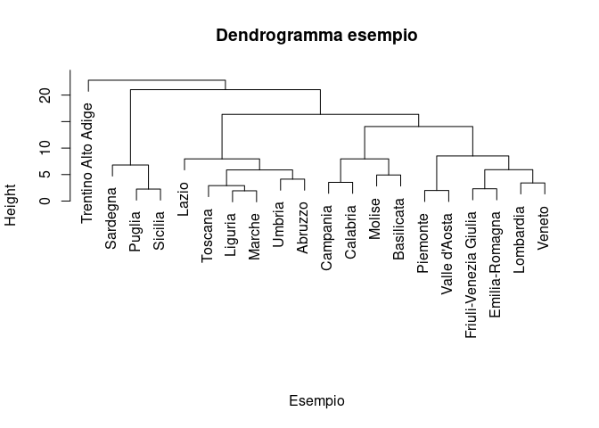

```r
plot(hclust(dist(matricePopolazionePerTitoloDiStudio),method="complete"),
     main ="Dendrogramma esempio",
     xlab="Esempio",sub="")
```

Prima di iniziare a vedere il clustering vero e proprio, introduciamo delle metriche che ci saranno utili per analizzare i nostri risultati.  
Prima di tutto vediamo cos’è uno **screeplot** e successivamente vediamo come **analizzare un dendrogramma** in maniera ottimale.

#### Screeplot

Lo screeplot è un **grafico** che rende più semplice la scelta su come partizionare un dendrogramma che si sta analizzando. **Sull’asse delle ordinate sono posti il numero di cluster ottenibili e sull’asse delle ascisse le distanze a cui avvengono le aggregazioni**.  
Se nel passaggio da **k a k-1 gruppi la distanza viene incrementata di molto**, allora è consigliabile tagliare il dendrogramma in k gruppi.  
Si tratta di un **metodo empirico** ed è consigliabile utilizzare le misure di non omogeneità statistiche (potrebbe suggerire una suddivisione errata).

Costruire uno screeplot è **sconsigliato con il metodo del centroide e della mediana** (vedremo in seguito che usano i **quadrati della distanza**) in quanto le agglomerazioni potrebbero verificarsi a livelli di distanza minore o uguale alle precedenti.  
Sono invece **di aiuto col metodo del legame singolo, completo e medio** in cui si utilizza una funzione di distanza.

#### Analisi del dendrogramma

R mette a disposizione varie funzioni per arricchire il dendrogramma e darci una visione più chiara o per aiutarci ad analizzarlo, vediamole:

- La funzione rect.hclust() ci dà la possibilità di **disegnare dei rettangoli intorno ai cluster** individuati in base all’altezza a cui vogliamo operare il taglio, oppure specificando il numero di cluster che vogliamo ottenere.
- La funzione cutree() ci consente di ottenere una **suddivisione degli individui in cluster** in corrispondenza di un livello o di un numero di cluster indicato. Ci restituisce o un vettore o una matrice in cui vengono specificati gli individui in quali cluster sono inseriti.
- La funzione aggregate() ci consente di ricavare **misure di sintesi** (media, varianza, deviazione standard, …) sui singoli cluster che si sono ottenuti

Ci sono poi le misure più importanti e su cui valuteremo effettivamente la bontà del nostro clustering: **misure di non omogeneità statistiche**.  
Come già detto infatti la traccia di T è univocamente determinata per ogni matrice che descrive p caratteristiche di n individui, allora fissato un numero m di suddivisioni, i cluster devono essere individuati in modo da **minimizzare** la misura di non omogeneità statistica interna ai cluster, e **massimizzare** la misura di non omogeneità statistica tra i gruppi.  
Considereremo vari metodi gerarchici e vedremo se con lo stesso numero di cluster ci conducono a due diverse partizioni: se capita bisogna scegliere quella che presenta la misura di non omogeneità statistica all’interno dei cluster più piccola ($trS$), cioè puntare ad avere una maggiore omogeneità interna ai cluster.

Dato che nel paragrafo successivo si dovranno calcolare le tracce della matrice di non omogeneità statistica tra i cluster, calcoliamo la **misura di non omogeneità totale**:

```r
numeroRighe <- nrow(matricePopolazionePerTitoloDiStudio)
trHI <- (numeroRighe-1) *sum(
  apply(matricePopolazionePerTitoloDiStudio,2, var ))
trHI
```

```
## [1] 1230.762
```

Vediamo dunque nel dettaglio i vari metodi gerarchici che abbiamo presentato nel paragrafo precedente.

#### Metodo legame singolo

Il metodo del **legame singolo**, detto anche *nearest neighbour method*, individua la distanza tra due cluster come la **distanza minima calcolata tra tutte le coppie** di individui in cui il primo individuo appartiene al primo cluster, mentre il secondo all’altro cluster preso in considerazione.

Al livello 0 l’algoritmo considera n cluster, uno per ogni individuo.
Al passo 1 si cerca la coppia di individui con la distanza minore e si uniscono in un unico cluster. Si modifica poi la matrice delle distanze scegliendo la distanza come la **minima** tra quella del primo individuo e quella del secondo individuo del nuovo cluster.
Ad ogni passo dopo che due cluster generici $G_u$ e $G_v$ sono stati uniti scegliendo la coppia di cluster meno distante, la distanza tra il nuovo cluster denotato $G_{uv}$ e un altro cluster $G_z$ è definita scegliendo dalla precedente matrice delle distanze:
$$d_{(uv),z} = \min (d_{uz},d_{vz})$$

Questo metodo ha il vantaggio di essere applicabile a gruppi di **qualsiasi forma** e di **evidenziare la presenza di eventuali valori anomali** meglio di altre tecniche, ma ha anche il difetto di basarsi su un singolo legame e non è raro che si possano trovare nello stesso cluster individui piuttosto dissimili: si potrebbero originare delle **catene**.  
Può capitare che due gruppi ben delineati e distinti vengono inseriti nello stesso gruppo erroneamente, dunque **non è sempre affidabile il legame singolo**.

Effettuiamo il calcolo dei cluster usando il metodo del legame singolo, e vediamo il campo merge dell’output che indica come sono state effettuate le aggregazioni nel corso della computazione:

```r
legameSingolo <- hclust(matriceDistanzeEuclidea,method="single")
legameSingolo$merge
```

```
##       [,1] [,2]
##  [1,]   -3  -11
##  [2,]   -1   -2
##  [3,]  -16  -19
##  [4,]   -7   -8
##  [5,]   -9    1
##  [6,]    4    5
##  [7,]   -4   -6
##  [8,]  -15  -18
##  [9,]  -13    6
## [10,]  -10    9
## [11,]    7   10
## [12,]    2   11
## [13,]    3    8
## [14,]  -17   12
## [15,]  -12   14
## [16,]  -14   15
## [17,]   13   16
## [18,]  -20   17
## [19,]   -5   18
```

Di seguito il dendrogramma e lo screeplot ottenuti utilizzando il metodo:

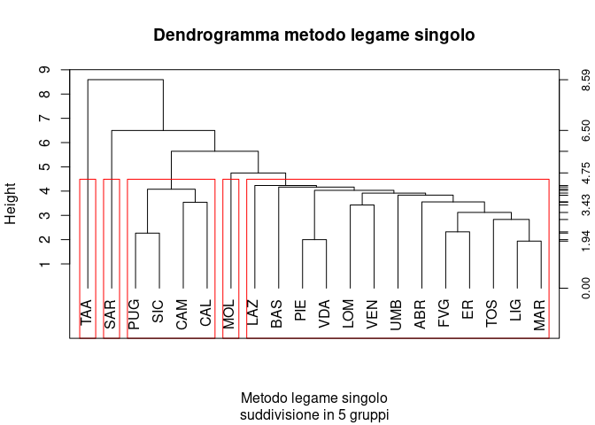

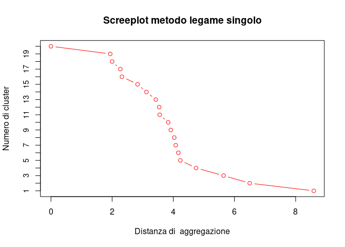

Valutiamo dunque partizionando in 3, 4 o 5 gruppi come cambia la **misura di non omogeneità statistica tra i cluster**.

Vediamo come calcoliamo la misura con un partizionamento in 3 gruppi:

```r
taglio <-cutree (legameSingolo , k =3, h = NULL)
num <-table (taglio )
tagliolist <- list(taglio)
agvar <- aggregate (matricePopolazionePerTitoloDiStudio, tagliolist , var)[, -1]

trH1 <-(num [[1]] -1) * sum(agvar [1, ])
if(is.na(trH1))
trH1 <- 0

trH2 <-(num [[2]] -1) *sum(agvar [2, ])
if(is.na(trH2))
trH2 <- 0

trH3 <-(num [[3]] -1) *sum(agvar [3, ])
if(is.na(trH3))
trH3 <- 0

sum <- trH1 + trH2 +trH3
trB <- trHI - sum
trB/trHI
```

```
## [1] 0.3212911
```

Il risultato ci dice che una suddivisione del genere non va affatto bene.

Con 4 gruppi il risultato è decisamente migliore, ci avviciniamo a una suddivisione buona.

```
## [1] 0.6700402
```

Con la suddivisione in 5 gruppi non cambia molto rispetto a quanto visto nel caso con 4, comunque sappiamo che il legame singolo si fa influenzare da valori anomali e sappiamo che ce ne sono ben due nel nostro dataset.

```
## [1] 0.6945096
```

#### Metodo legame completo

Il metodo del **legame completo**, detto anche *furthest neighbour method*, individua la distanza tra due cluster come la **distanza massima calcolata tra tutte le coppie** di individui in cui il primo individuo appartiene al primo cluster, mentre il secondo all’altro cluster preso in considerazione.

Al livello 0 l’algoritmo considera n cluster, uno per ogni individuo.
Al passo 1 si cerca la coppia di individui con la distanza minore e si uniscono in un unico cluster. Si modifica poi la matrice delle distanze scegliendo la distanza con gli altri cluster individuata come la maggiore tra quella del primo individuo e quella del secondo individuo del nuovo cluster.
Ad ogni passo dopo che due cluster generici $G_u$ e $G_v$ sono stati uniti scegliendo la coppia di cluster meno distante, la distanza tra il nuovo cluster denotato $G_{uv}$ e un altro cluster $G_z$ è definita scegliendo dalla precedente matrice delle distanze:
$$d_{(uv),z} = \max (d_{uz},d_{vz})$$

Questo metodo è adatto per gruppi che si **addensono intorno a un elemento centrale**.  
Viene privilegiata l’**omogeneità dei gruppi** e si **evita l’effetto catena**.  
Si nota inoltre che il dendrogramma costruito con questo metodo ha **rami più lunghi** poiché le distanze sono maggiori. In linea generale il metodo del legame completo è ottimo da utilizzare.

Effettuiamo il calcolo dei cluster usando il metodo del legame completo, e vediamo il campo merge dell’output che indica come sono state effettuate le aggregazioni nel corso della computazione:

```r
legameCompleto <- hclust(matriceDistanzeEuclidea,method="complete")
legameCompleto$merge
```

```
##       [,1] [,2]
##  [1,]   -3  -11
##  [2,]   -1   -2
##  [3,]  -16  -19
##  [4,]   -7   -8
##  [5,]   -9    1
##  [6,]   -4   -6
##  [7,]  -15  -18
##  [8,]  -10  -13
##  [9,]  -14  -17
## [10,]    5    8
## [11,]    4    6
## [12,]  -20    3
## [13,]    7    9
## [14,]  -12   10
## [15,]    2   11
## [16,]   13   15
## [17,]   14   16
## [18,]   12   17
## [19,]   -5   18
```

Di seguito il dendrogramma e lo screeplot ottenuti utilizzando il metodo:

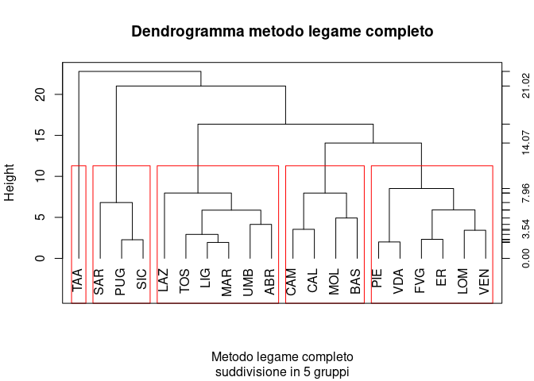

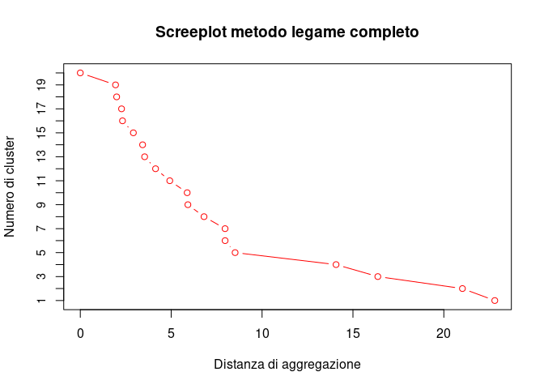

Valutiamo dunque partizionando in 3, 4 o 5 gruppi come cambia la **misura di non omogeneità statistica tra i cluster**.

Una divisione in 3 gruppi va scartata in quanto non raggiungiamo una misura adeguata.

```
## [1] 0.5238758
```

Anche partizionando in 4 cluster non raggiungiamo un risultato positivo, va scartata anche questa suddivisione.

```
## [1] 0.6390021
```

Con 5 cluster invece raggiungiamo un **risultato ottimo**, il migliore ottenuto fino ad ora. Anche dal dendrogramma è evidente che questa suddivisione è ottima.

```
## [1] 0.8118917
```

#### Metodo legame medio

Il metodo del **legame medio**, detto anche *average linkage method*, individua la distanza tra due cluster come la **media aritmetica delle distanze tra tutte le coppie di individui che compongono due gruppi**.

Al livello 0 l’algoritmo considera n cluster, uno per ogni individuo.
Al passo 1 si cerca la coppia di individui con la distanza minore e si uniscono in un unico cluster. Si modifica poi la matrice delle distanze scegliendo la distanza con gli altri cluster: viene individuata come la **media calcolata** tra i nuovi elementi del cluster (unione degli elementi dei due cluster aggregati) con gli altri insiemi già presenti.
Ad ogni passo dopo che due cluster generici $G_u$ e $G_v$ sono stati uniti scegliendo la coppia di cluster meno distante, la distanza tra il nuovo cluster denotato $G_{uv}$ e un altro cluster $G_z$ è definita effettuando il calcolo di seguito in base alla matrice delle distanze precedente:
$$d_{(uv),z} = \frac{N_u}{N_u + N_v} d_{uz} + \frac{N_v}{N_u + N_v}d_{vz}$$

Dove $N_u$ e $N_v$ sono individui nel cluster $G_u$ e $G_v$. $d_{(uv),z}$ rappresenta la misura di **distanza media tra gli elementi dei cluster** $G_uv$ e $G_z$. La procedura si ripete fino ad ottenere un unico cluster formato da tutti gli individui.

Questo metodo ha il seguente svantaggio: se il numero di elementi dei due cluster che si uniscono è molto diverso, la **distanza sarà più vicina a quella del cluster più numeroso**.

Effettuiamo il calcolo dei cluster usando il metodo del legame medio, e vediamo il campo merge dell’output che indica come sono state effettuate le aggregazioni nel corso della computazione:

```r
legameMedio <- hclust(matriceDistanzeEuclidea,method="average")
legameMedio$merge
```

```
##       [,1] [,2]
##  [1,]   -3  -11
##  [2,]   -1   -2
##  [3,]  -16  -19
##  [4,]   -7   -8
##  [5,]   -9    1
##  [6,]   -4   -6
##  [7,]  -15  -18
##  [8,]  -10  -13
##  [9,]    4    5
## [10,]  -14  -17
## [11,]    2    6
## [12,]    3    7
## [13,]    8    9
## [14,]   10   13
## [15,]   11   14
## [16,]  -20   12
## [17,]  -12   15
## [18,]   16   17
## [19,]   -5   18
```

Di seguito il dendrogramma e lo screeplot ottenuti utilizzando il metodo:

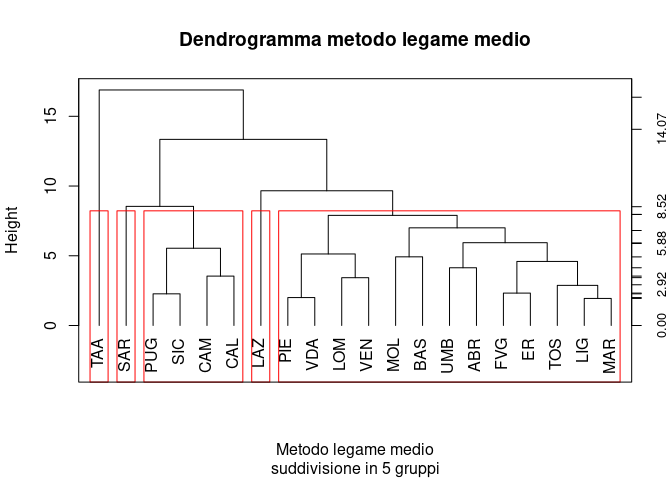

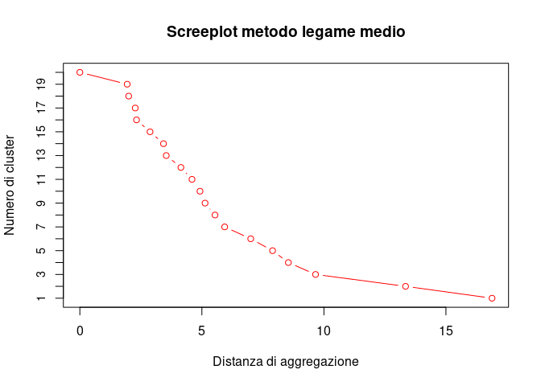

Valutiamo dunque partizionando in 3, 4 o 5 gruppi come cambia la **misura di non omogeneità statistica tra i cluster**.

Una divisione in 3 gruppi rispetto ai casi precedenti da un risultato migliore, vediamo gli altri.

```
## [1] 0.6255962
```

La divisione in 4 gruppi non migliora sostanzialmente la divisione con 3, questo ci fa pensare che il clustering non sia stato effettuato in maniera ottimale.

```
## [1] 0.684957
```

Come predetto il risultato con 5 gruppi è deludente, il metodo del legame completo ci ha dato un risultato sicuramente più soddisfacente. in maniera ottimale.

```
## [1] 0.729401
```

#### Metodo del centroide

Il metodo del **centroide** individua la distanza tra due gruppi come la distanza tra i **centroidi**, la **distanza tra le medie campionarie calcolate sugli individui appartenenti ai due gruppi**.

Per questo metodo viene usata la matrice che contiene i **quadrati delle singole distanze euclidee**.

Questo metodo può portare gruppi di grandi dimensioni a portare dentro di se piccoli gruppi (**fenomeni gravitazionali**).  
Analogamente a prima se uno dei due gruppi uniti ha una numerosità maggiore all’altro, allora il centroide risultante sarà molto vicino a quello del cluster più numeroso.

Calcoliamo dunque la matrice dei quadrati delle singole distanze euclidee che ci servirà per applicare il metodo:

```r
matriceDistanzeEuclideaQuadrato <- matriceDistanzeEuclidea^2
```

Effettuiamo il calcolo dei cluster usando il metodo del centroide, e vediamo il campo merge dell’output che indica come sono state effettuate le aggregazioni nel corso della computazione:

```r
metodoCentroide <- hclust(matriceDistanzeEuclideaQuadrato,method="centroid")
metodoCentroide$merge
```

```
##       [,1] [,2]
##  [1,]   -3  -11
##  [2,]   -1   -2
##  [3,]  -16  -19
##  [4,]   -7   -8
##  [5,]   -9    1
##  [6,]   -4   -6
##  [7,]  -15  -18
##  [8,]  -10  -13
##  [9,]    5    8
## [10,]    4    6
## [11,]  -14  -17
## [12,]    9   11
## [13,]    3    7
## [14,]    2   10
## [15,]   12   14
## [16,]  -20   13
## [17,]  -12   15
## [18,]   16   17
## [19,]   -5   18
```

In questo caso calcoliamo solo il dendrogramma visto che lo screeplot non è molto utile per questo metodo (e il successivo che vedremo).  
Di seguito il dendrogramma dunque:

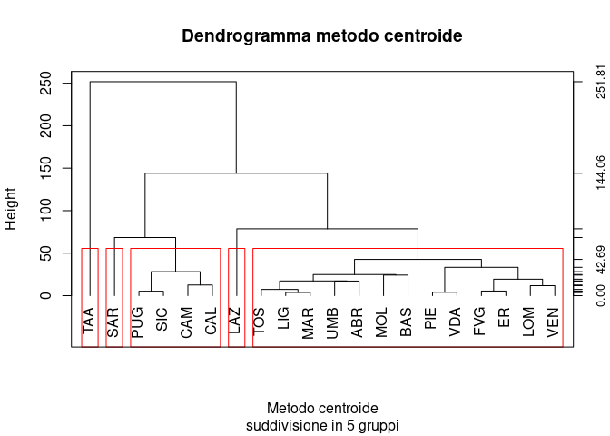

Valutiamo dunque partizionando in 3, 4 o 5 gruppi come cambia la **misura di non omogeneità statistica tra i cluster**.

Una divisione in 3 gruppi non dà un risultato molto buono:

```
## [1] 0.6255962
```

Anche il risultato con 4 gruppi non è entusiasmante:

```
## [1] 0.684957
```

Con 5 gruppi raggiungiamo una soglia buona, ma col metodo del legame completo abbiamo raggiunto un risultato migliore:

```
## [1] 0.729401
```

#### Metodo della mediana

Infine è stato utilizzato anche il metodo della mediana senza nessun risultato significativo.

```r
metodoMediana <- hclust(matriceDistanzeEuclideaQuadrato,method="median")
metodoMediana$merge
```

```
##       [,1] [,2]
##  [1,]   -3  -11
##  [2,]   -1   -2
##  [3,]  -16  -19
##  [4,]   -7   -8
##  [5,]   -9    1
##  [6,]   -4   -6
##  [7,]  -15  -18
##  [8,]  -10  -13
##  [9,]    5    8
## [10,]    4    6
## [11,]  -14  -17
## [12,]    9   11
## [13,]    3    7
## [14,]    2   10
## [15,]   12   14
## [16,]  -20   13
## [17,]  -12   15
## [18,]   16   17
## [19,]   -5   18
```

Il corrispondente dendrogramma è il seguente:

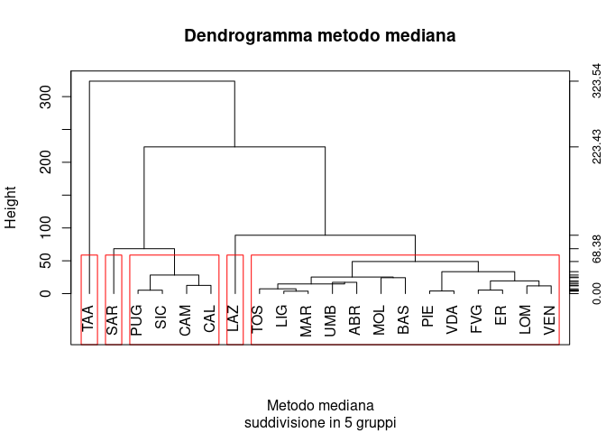

Di seguito la misura di non omogeneità statistica ottenuta con 3, 4 e 5 cluster:

```
## [1] 0.6255962
```

```
## [1] 0.684957
```

```
## [1] 0.729401
```

In conclusione da questa analisi abbiamo individuato che il **clustering migliore lo otteniamo utilizzando il metodo del legame completo con 5 cluster**.  
Il clustering ottenuto è dunque:

```
##              Piemonte         Valle d'Aosta               Liguria
##                     1                     1                     2
##             Lombardia   Trentino Alto Adige                Veneto
##                     1                     3                     1
## Friuli-Venezia Giulia        Emilia-Romagna               Toscana
##                     1                     1                     2
##                Umbria                Marche                 Lazio
##                     2                     2                     2
##               Abruzzo                Molise              Campania
##                     2                     4                     4
##                Puglia            Basilicata              Calabria
##                     5                     4                     4
##               Sicilia              Sardegna
##                     5                     5
```

$C_1 = \{Piemonte, Valle D'aosta, Lombardia, Veneto, Friuli-Venezia\ Giulia,Emilia-Romagna\}$  
$C_2 = \{Liguria,Toscana,Umbria,Marche,Lazio,Abruzzo\}$  
$C_3 = \{Trentino Alto Adige\}$  
$C_4 = \{Molise,Campania,Basilicata,Calabria\}$  
$C_5 = \{Puglia,Sicilia,Sardegna\}$

La misura di non omogeneità statistica tra cluster ottenuta è pari a:

```
## [1] 0.8118917
```

Passiamo dunque all’analisi con i **metodi non gerarchici** per migliorare ulteriormente il partizionamento ottenuto.

## Metodi non gerarchici

A differenza dei metodi gerarchici, con i metodi non gerarchici **possiamo ricollocare gli individui** già classificati in un livello precedente dell’analisi.  
Quello che si vuole ottenere con questi metodi è una **partizione unica** degli n individui.  
In molti metodi non gerarchici **numero di cluster va precisato all’inizio dell’analisi**, mentre in alcuni viene determinato nel corso dell’analisi stessa.

Generalmente un metodo non gerarchico, data una partizione iniziale, procedono riallocando gli individui nel gruppo con il **centroide più vicino**, fino ad arrivare al passo in cui per ogni individuo la **distanza rispetto al centroide del proprio gruppo è minima**.  
Il metodo più utilizzato è **k-means**. Per questo metodo bisogna specificare il numero di cluster che si vuole ottenere a priori.

Vediamo dunque i passi di seguito:

1. **Specificare a priori il numero k di cluster e specificare m punti di riferimento iniziali** per produrre una prima partizione provvisoria
2. Per ogni individuo determinare il cluster di appartenenza, cioè quello individuato dal **punto di riferimento da cui ha distanza minore**
3. Calcolare il **centroide di ognuno dei k gruppi ottenuti**: questi centroidi sono i punti di riferimento per i nuovi cluster
4. **Rivaluta la distanza di ogni individuo da ogni centroide** e nel caso in cui la distanza minima sia col centroide di un altro gruppo, l’individuo viene spostato in quel gruppo.
5. Si **ricalcolano i centroidi**
6. Si ripete il passo 4 e 5 **finché non si arriva al punto che nessun individuo viene spostato**

Come misura di distanza viene utilizzata la **distanza euclidea** e si considerano i **quadrati della matrice delle distanze**.

Non si tratta di un metodo di ottimizzazione, infatti **si ottengono ottimi locali**: in base alla partizione iniziale possono ottenere risultati migliori.

Applichiamo dunque k-means alla nostra matrice come input il un **numero di cluster pari a 5** in accordo a quanto ottenuto analizzando con i metodi gerarchici. Si noti che per essere sicuri di trovare una buona suddivisione tra tutte quelle possibili, nstart è posto a 10 dunque ci saranno dieci tentativi e il numero masso di iterazioni è posto a 20.

```r
km <- kmeans (matricePopolazionePerTitoloDiStudio, centers = 5 ,
              iter.max = 20, nstart = 10)
km
```

```
## K-means clustering with 5 clusters of sizes 8, 3, 1, 4, 4
##
## Cluster means:
##   Nessun titolo    Medie   Diploma Maturità  Laurea
## 1         4.225 31.95000  9.425000 34.96250 19.4625
## 2         8.500 33.43333  3.233333 37.66667 17.1000
## 3         3.200 29.20000 19.500000 29.20000 18.8000
## 4         9.950 39.85000  2.675000 32.65000 14.8250
## 5         4.050 29.45000  4.950000 40.27500 21.2750
##
## Clustering vector:
##              Piemonte         Valle d'Aosta               Liguria
##                     1                     1                     1
##             Lombardia   Trentino Alto Adige                Veneto
##                     1                     3                     1
## Friuli-Venezia Giulia        Emilia-Romagna               Toscana
##                     1                     1                     5
##                Umbria                Marche                 Lazio
##                     5                     1                     5
##               Abruzzo                Molise              Campania
##                     5                     2                     4
##                Puglia            Basilicata              Calabria
##                     4                     2                     2
##               Sicilia              Sardegna
##                     4                     4
##
## Within cluster sum of squares by cluster:
## [1] 101.0075  32.6400   0.0000  52.1250  40.4050
##  (between_SS / total_SS =  81.6 %)
##
## Available components:
##
## [1] "cluster"      "centers"      "totss"        "withinss"
## [5] "tot.withinss" "betweenss"    "size"         "iter"
## [9] "ifault"
```

L’output di k-means ci dice che dal clustering ottenuto tramite l’algoritmo risulta che la misura di non omogeneità statistica tra cluster è pari a:

```r
km$betweenss/km$totss
```

```
## [1] 0.8162298
```